# Food and You analyses_How confident are you that the information on food labels is accurate 01122023

Constanza Avalos

2023-12-01

## Food and You 2: Waves 1-6, 2020-2023

In 2018, the FSA’s Advisory Committee for Social Science (ACSS) recommended that Food and You and the Public Attitudes Tracker were replaced with a new ‘push-to-web’ survey, Food and You 2, which was commissioned in 2019 with data collection commencing in July 2020. Due to differences in the survey methodologies, comparisons cannot be made between the earlier Food and You surveys, or the Public Attitudes Tracker, and Food and You 2. Therefore Food and You 2, 2020 is the start of a new data time series.

Technical features:

Dates of fieldwork: Wave 1: 28 July - 6 October 2020; Wave 2: 20 November 2020 - 21 January 2021; Wave 3: 28 April - 25 June 2021; Wave 4: 18 October 2021 - 10 January 2022; Wave 5: 26 April - 24 July 2022. Wave 6: 12 October 2022 - 10 January 2023

Observation units: Individuals

Number of units: Wave 1: 9,319 cases; Wave 2: 5,900; Wave 3: 6,271; Wave 4: 5,796; Wave 5: 6,770; Wave 6: 5,991

Method of data collection: a) Self-administered questionnaire: Web-based (CAWI) and b) Self-administered questionnaire: Paper

Time dimensions: Repeated cross-sectional study

Sampling procedures: Multi-stage stratified random sample

Weighting: Weighting used. See documentation for details

```r
library(readxl)
Wave_1 <- read_excel("C:/Users/const/OneDrive/Desktop/PhD/R/Food and You 2 Waves 1-6, 2020-2023/Wave 1.xlsx")
Wave_2 <- read_excel("C:/Users/const/OneDrive/Desktop/PhD/R/Food and You 2 Waves 1-6, 2020-2023/Wave 2.xlsx")
Wave_3 <- read_excel("C:/Users/const/OneDrive/Desktop/PhD/R/Food and You 2 Waves 1-6, 2020-2023/Wave 3.xlsx")
Wave_4 <- read_excel("C:/Users/const/OneDrive/Desktop/PhD/R/Food and You 2 Waves 1-6, 2020-2023/Wave 4.xlsx")
Wave_5 <- read_excel("C:/Users/const/OneDrive/Desktop/PhD/R/Food and You 2 Waves 1-6, 2020-2023/Wave 5.xlsx")
Wave_6 <- read_excel("C:/Users/const/OneDrive/Desktop/PhD/R/Food and You 2 Waves 1-6, 2020-2023/Wave 6.xlsx")
```

## Grouped plots

How confident are you that the information on food labels is accurate (e.g. ingredients, nutritional information, country of origin)? (Single answer), all waves.

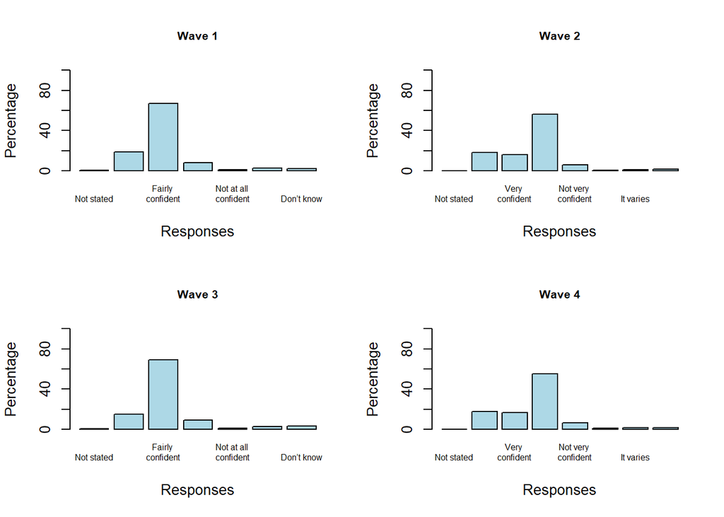

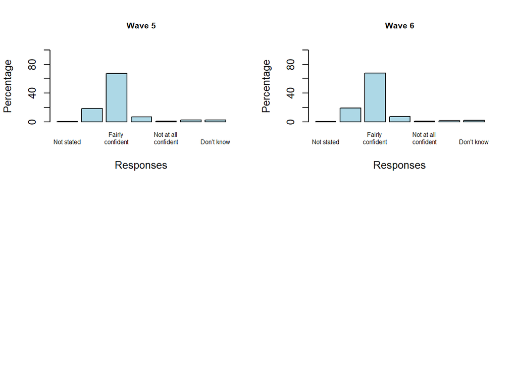

## Single Plots

Q30, 40 Q31 Q36 How confident are you that the information on food labels is accurate (e.g. ingredients, nutritional information, country of origin)? (Single answer), all waves.

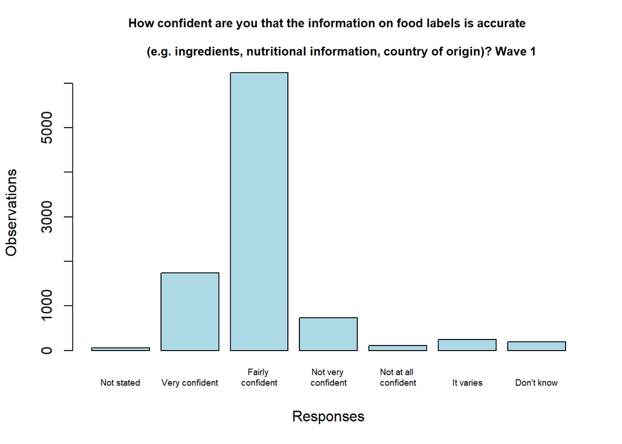

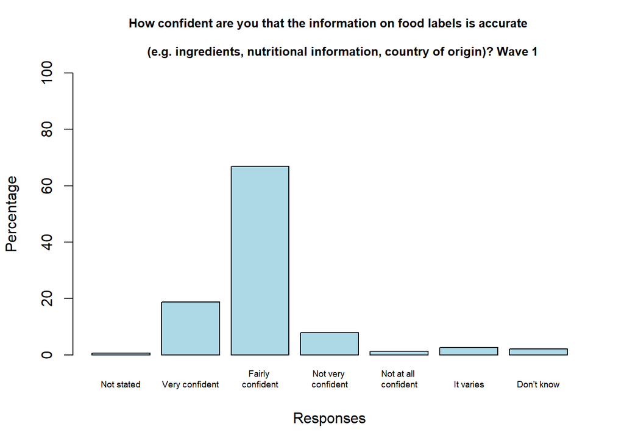

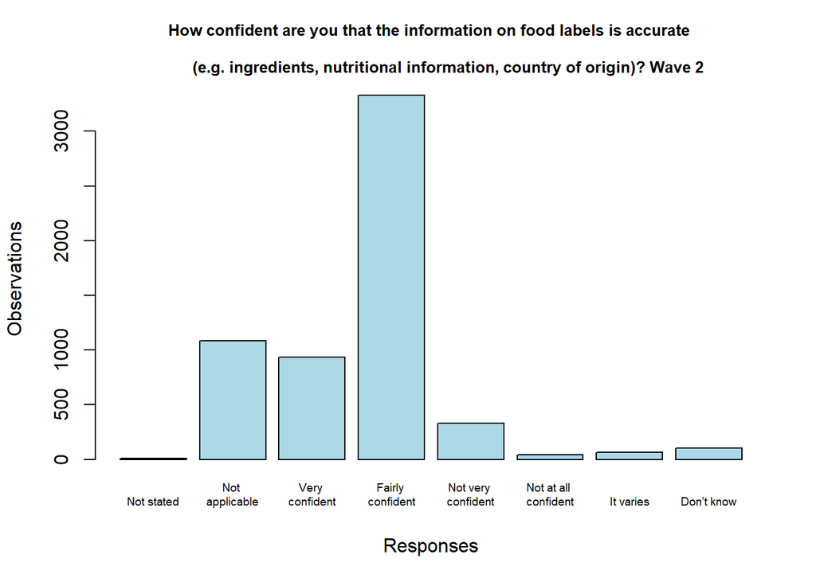

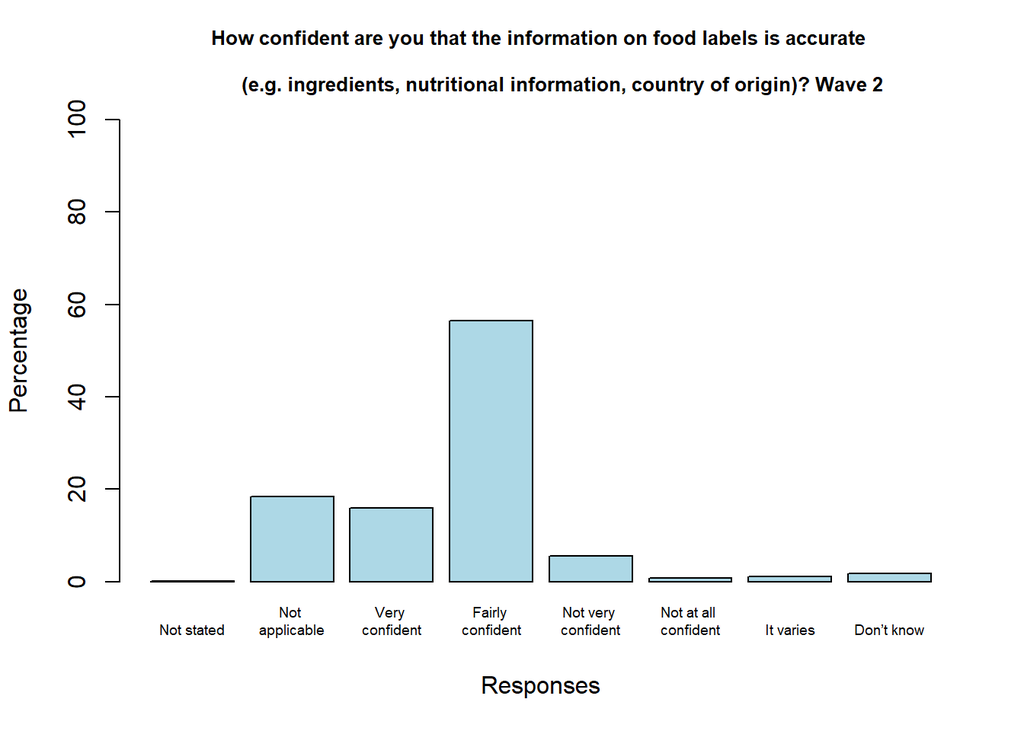

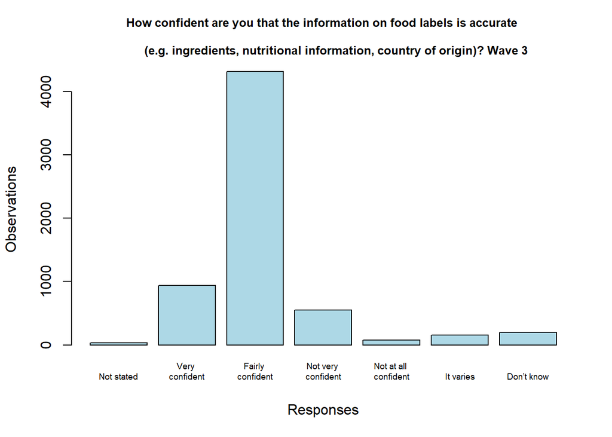

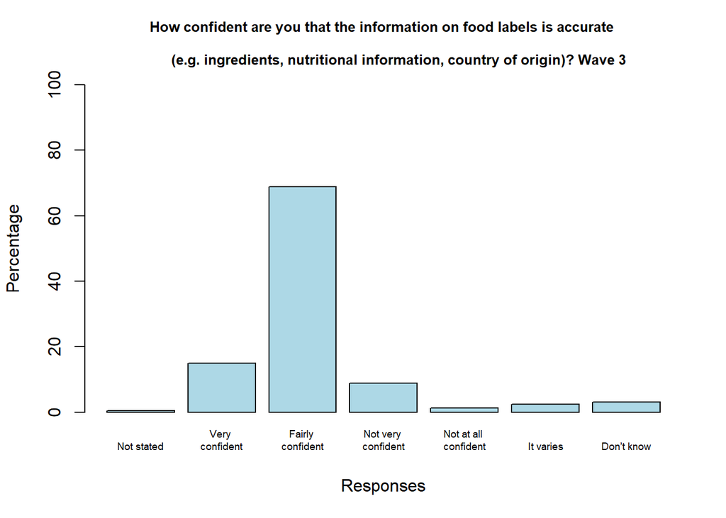

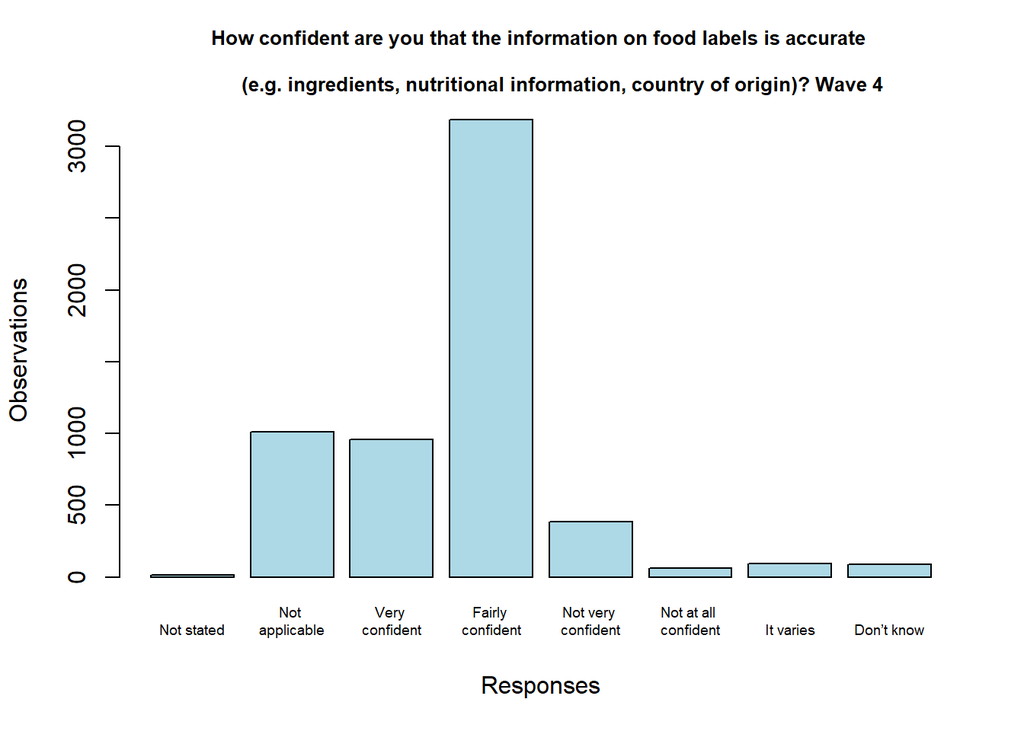

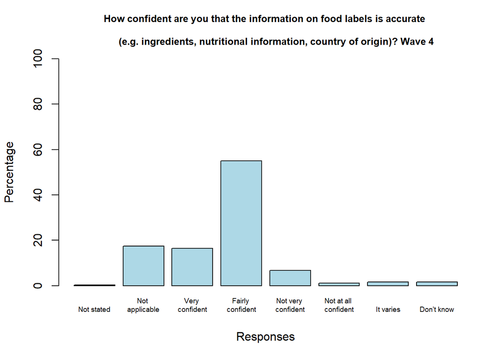

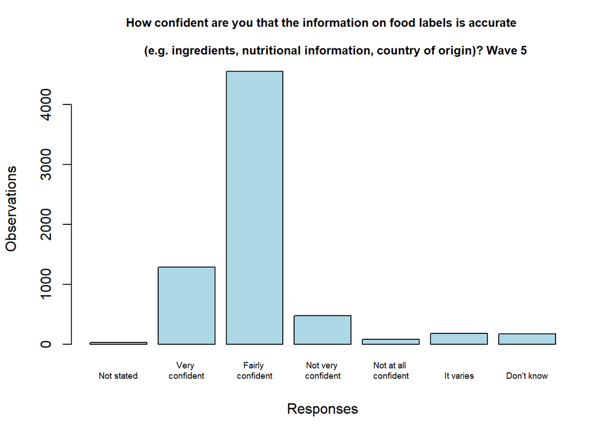

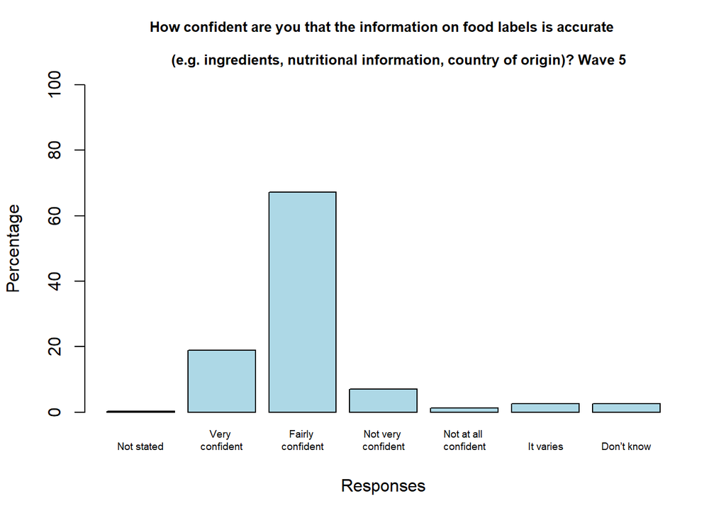

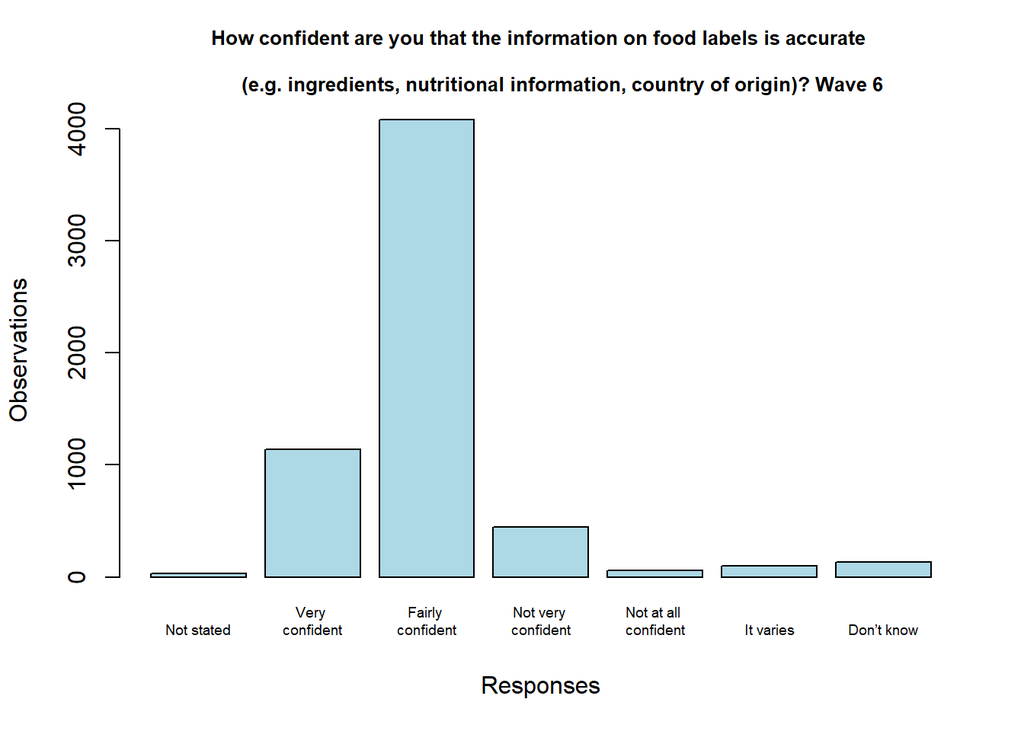

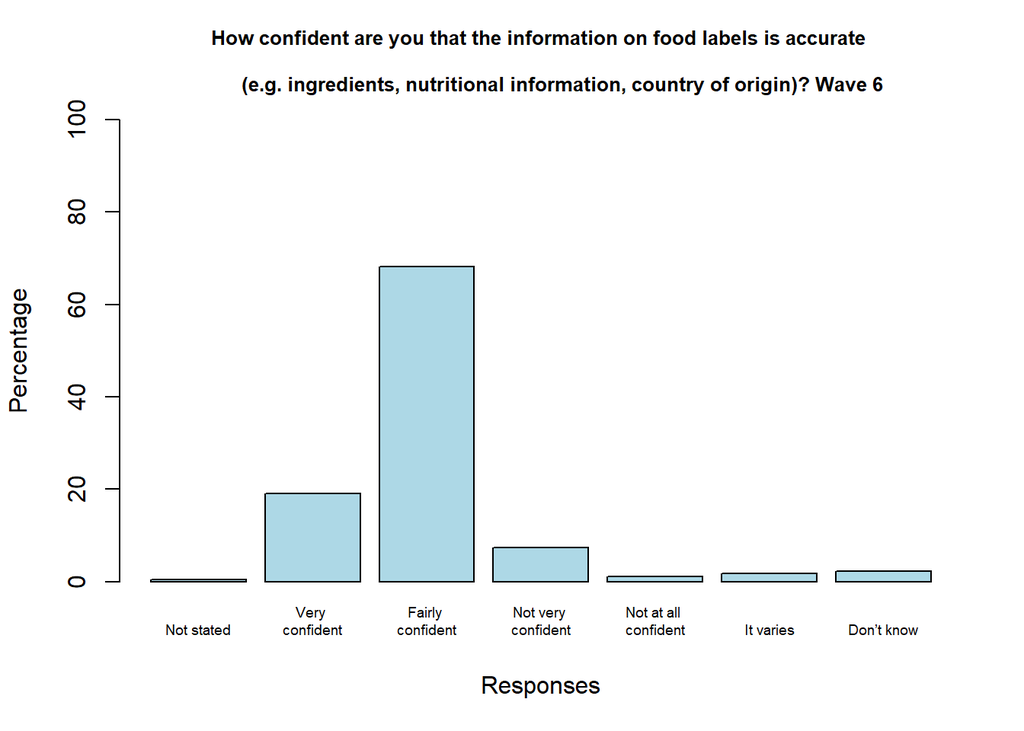